# Analysis of Model F

IMA tumor modeling team

11 October, 2017

### Analysis on Model F

```r
suppressMessages(source("ams_initialize_script.R"))
suppressMessages(library(RxODE))
suppressMessages(library(dplyr))
```

# Model F is defined below

```r
source("ivsc_4cmtct_shedct.R")
```

```r
# Global Variables
model = ivsc_4cmtct_shedct()
tmax  = 10*28 # End of the observation time, unit=day
tau   = 1 # dosing interval, unit=day
compartment = 2 # compartment to which dosing is applied

# Import parameters
d = readxl::read_excel("../data/ivsc_4cmtct_shedct_param.xlsx",1)
param.as.double = d$Value
names(param.as.double) = d$Parameter

# Helper function to make the range of a variable when performing sensitivity analysis
lseq = function(from, to, length.out){
    sequence = seq(log(from), log(to), length.out=length.out)
    sequence = exp(sequence)
    return(sequence)
}
```

# The function below calculates AFIRT from theory

Argument: dose amount in nmol Return: theoretical AFIRT for both Kss and Kd

```r
AFIRT_theory = function(dose.nmol){
    p = as.data.frame(t(param.as.double))
    Kss = with(p, (koff3 + keDM3 + kshedM3)/kon3)
    Kd = with(p, koff3 / kon3)

    # numerator and denomenator for Mtot3.ss(Mtot3 at steady state)
    numerator   = with(p, k13DM*(VD1/VD3)*ksynM1+(keDM1+kshedM1+k13DM)*ksynM3)
    denomenator = with(p, (keDM1+kshedM1+k13DM)*(keDM3+kshedM3+k31DM)-k31DM*k13DM)
    Mtot3.ss = numerator / denomenator

    # numerator and denomenator for M3.0 (M3 at initial state)
    numerator   = with(p, k13M*(VD1/VD3)*ksynM1+(keM1+kshedM1+k13D)*ksynM3)
    denomenator = with(p, (keM1+kshedM1+k13D)*(keD3+kshedM3+k31D)-k31D*k13D)
    M3.0 = numerator / denomenator

    # Target accumulation in the tumor compartment
    Tacc.tum = Mtot3.ss / M3.0

    CL = with(p, keD1 * VD1)
    B  = with(p, (k13D*VD1/VD3)/(keD3 + k31D))

    AFIRT.theory.Kss = Kss*Tacc.tum*(CL*tau)/(dose.nmol*B)
    AFIRT.theory.Kd  = Kd*Tacc.tum*(CL*tau)/(dose.nmol*B)
    return(c(AFIRT.theory.Kss, AFIRT.theory.Kd))
}
```

# The function below simulates AFIRT as the average of free target to initial target

Argument: dose amount in nmol Return: simulated AFIRT

Note: This function computes AFIRT as the average of M3/M3.0 when time is in (56, 84).

```r
AFIRT_sim = function(dose.nmol){
  ev = eventTable(amount.units="nmol", time.units="days")
  sample.points = c(seq(-7, tmax, 0.1), 10^(-3:0)) # sample time, increment by 0.1
  sample.points = sort(sample.points)
  sample.points = unique(sample.points)
  ev$add.sampling(sample.points)
  ev$add.dosing(dose=dose.nmol, nbr.doses=floor(tmax/tau)+1, dosing.interval=tau,
                dosing.to=2)

  init = model$init(param.as.double)
  out = model$rxode$solve(param.as.double, ev, init)
  out = model$rxout(out)
  out = out %>%
    mutate(Sfree.pct = S1/init["S1"],
             Mfree.pct = M3/init["M3"],
             dose.nmol = dose.nmol)

  last.two.doses = out %>%
    filter(time > 2*28 & time < 3*28)

  AFIRT.sim = mean(last.two.doses$Mfree.pct)

  return(AFIRT.sim)
}
```

# The function below performs sensitivity analysis for AFIRT

```r
sensitivity_analysis_for_AFIRT = function(dose.nmol, variable, range){
    df = data.frame()
    for (value in range){
        param.as.double[variable] = value
        AFIRT.sim = AFIRT_sim(dose.nmol)
        AFIRT.theory = AFIRT_theory(dose.nmol)
        row = append(c(value, AFIRT.sim), AFIRT.theory)
        df = rbind(df, row)
    }
    colnames(df) = c(variable, "AFIRF.sim", "AFIRT.theory.Kss", "AFIRT.theory.Kd")
    return(df)
}
```

# This function plots the sensitivity analysis for AFIRT

Basically, it puts the data frame returned from sensitivity_analysis_for_AFIRT onto a picture

```r
plot.AFIRT.sensitivity.analysis = function(data, filename){
    names = names(data)
    data = data %>% gather(key, value, -c(get(names[1])))
    g = ggplot(data, aes(get(names[1]), value, color=key)) +
        scale.x.log10() +
        scale.y.log10() +
        geom_point() +
        geom_line() +
        ylab("AFIRT") +
        xlab(names[1])
    ggsave(filename, g)
    return(g)
}
```

# This fuction simulates Model F

Argument: dose.nmol: dose amount in nmol params_file_path: full path of the parameter file Return: A data frame containing all the compartments of the model

Note: dose amount is sent to the second compartment (or the second differential equation)

```r
simulation = function(dose.nmol, params_file_path){
  d <- xlsx::read.xlsx(params_file_path, 1)
  param.as.double = d$Value
  names(param.as.double) = d$Parameter
  ev = eventTable(amount.units="nmol", time.units="days")
  sample.points = c(seq(-7, tmax, 0.1), 10^(-3:0)) # sample time, increment by 0.1
  sample.points = sort(sample.points)
  sample.points = unique(sample.points)
  ev$add.sampling(sample.points)
  ev$add.dosing(dose=dose.nmol, nbr.doses=floor(tmax/tau)+1, dosing.interval=tau,
                dosing.to=2)

  init = model$init(param.as.double)
  out = model$rxode$solve(param.as.double, ev, init)
  out = model$rxout(out)
  out = out %>%
    mutate(Sfree.pct = S1/init["S1"],
             Mfree.pct = M3/init["M3"],
             dose.nmol = dose.nmol)
  return(out)
}

dose.nmol = 80
df = simulation(dose.nmol, "../data/ModelF_Atezolizumab_Params.xlsx")
```

# Here is how the simulated output looks like for time > 0

```r
dose_applied = df %>%
  filter(time >0)
dose_applied %>%
  head(5) %>%
  signif(2) %>%
  kable()
```

| time | AmtD0 | AmtD1 | D2 | D3 | S1 | S3 | M1 | M3 | DS1 | DS3 | DM1 | DM3 | D1 | Dtot1 | Stot1 | Dtot3 | Stot3 | Mtot1 | Mtot3 | Sfree.pct | Mfree.pct | dose.nmol |
| --- | --- | --- | --- | --- | --- | --- | --- | --- | --- | --- | --- | --- | --- | --- | --- | --- | --- | --- | --- | --- | --- | --- |
| 0.001 | 0 | 80 | 0.0037 | 0.0036 | 3.70 | 9.7 | 0.290 | 2.6 | 0.11 | 0.00003 | 0.0086 | 3.4e-05 | 24 | 24 | 3.8 | 0.0037 | 9.7 | 0.3 | 2.6 | 0.97 | 1.00 | 80 |
| 0.010 | 0 | 79 | 0.0360 | 0.0340 | 2.80 | 9.7 | 0.230 | 2.5 | 0.94 | 0.00280 | 0.0730 | 3.0e-03 | 24 | 25 | 3.8 | 0.0370 | 9.7 | 0.3 | 2.6 | 0.75 | 1.00 | 80 |
| 0.100 | 0 | 75 | 0.3500 | 0.2000 | 0.53 | 9.5 | 0.062 | 2.5 | 3.30 | 0.17000 | 0.2400 | 9.7e-02 | 23 | 26 | 3.8 | 0.3700 | 9.7 | 0.3 | 2.6 | 0.14 | 0.96 | 80 |
| 0.100 | 0 | 75 | 0.3500 | 0.2000 | 0.53 | 9.5 | 0.062 | 2.5 | 3.30 | 0.17000 | 0.2400 | 9.7e-02 | 23 | 26 | 3.8 | 0.3700 | 9.7 | 0.3 | 2.6 | 0.14 | 0.96 | 80 |
| 0.200 | 0 | 73 | 0.6800 | 0.3000 | 0.41 | 9.2 | 0.055 | 2.4 | 3.50 | 0.44000 | 0.2400 | 1.6e-01 | 22 | 26 | 3.9 | 0.7400 | 9.7 | 0.3 | 2.6 | 0.11 | 0.94 | 80 |

# D1 (drug) against time

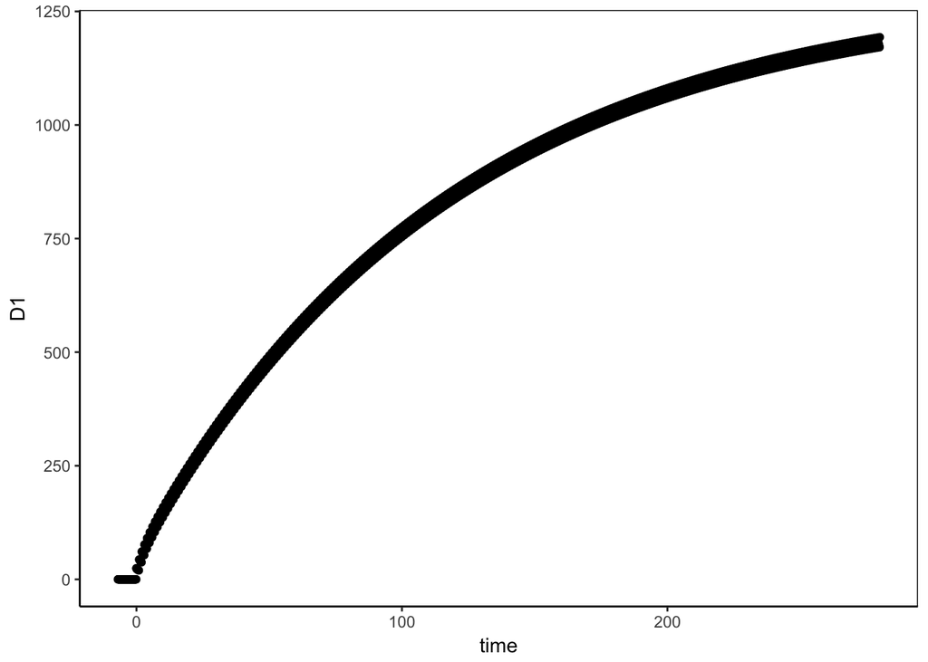

```r
g = ggplot(df, aes(time, D1)) + geom_point()
print(g)
```

# D3 (drug) against time

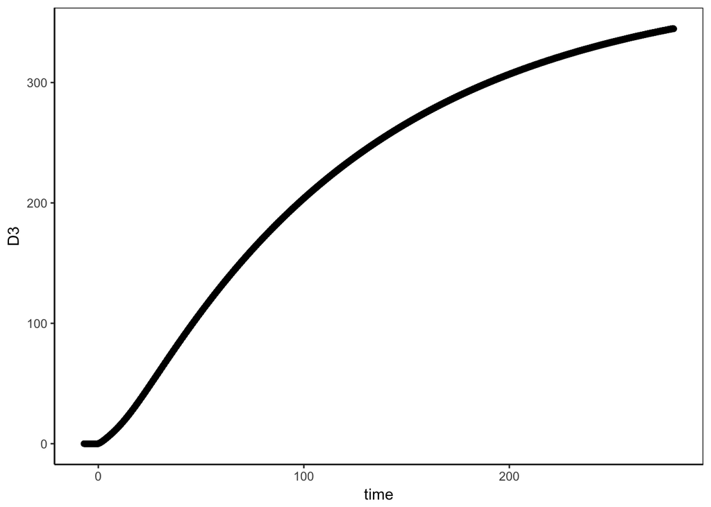

```r
g = ggplot(df, aes(time, D3)) + geom_point()
print(g)
```

# DM3 (complex) against time

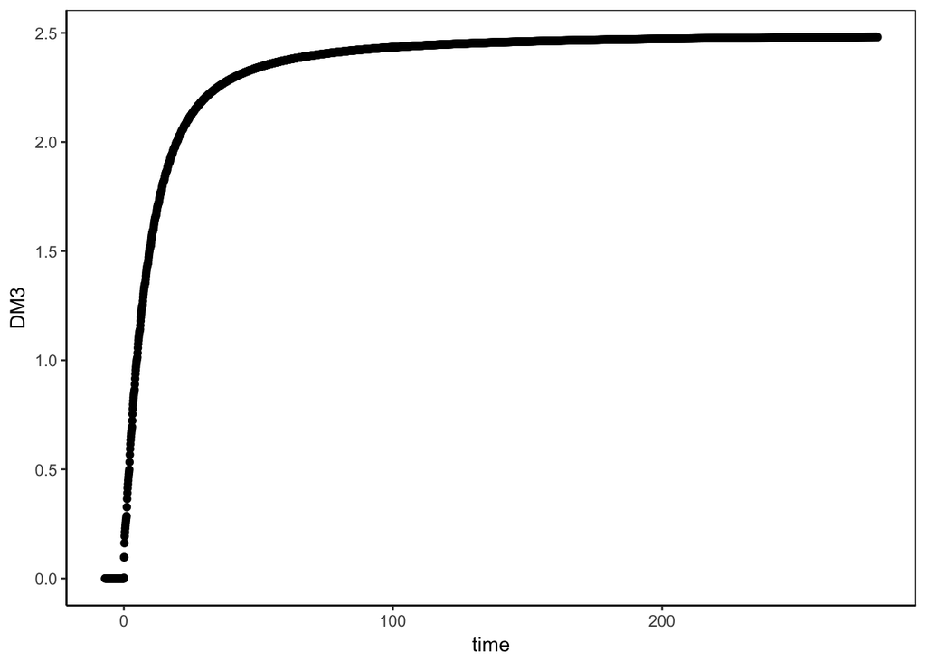

```r
g = ggplot(df, aes(time, DM3)) + geom_point()
print(g)
```

# M3 (free target) against time

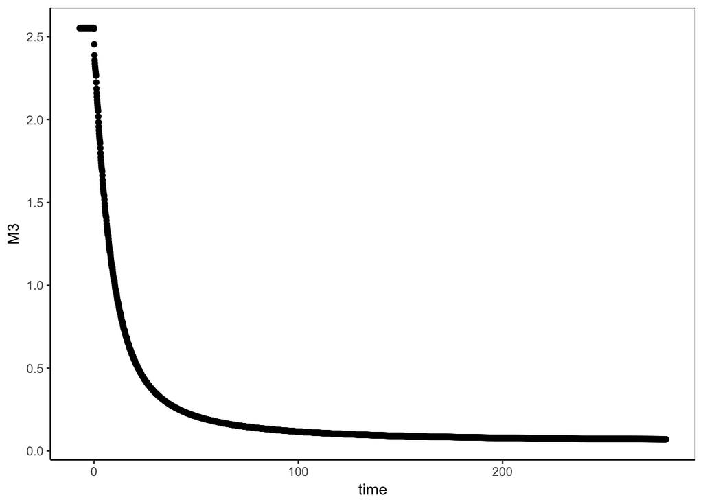

```r
g = ggplot(df, aes(time, M3)) + geom_point()
print(g)
```

# Mfree (free target to initial target) against time

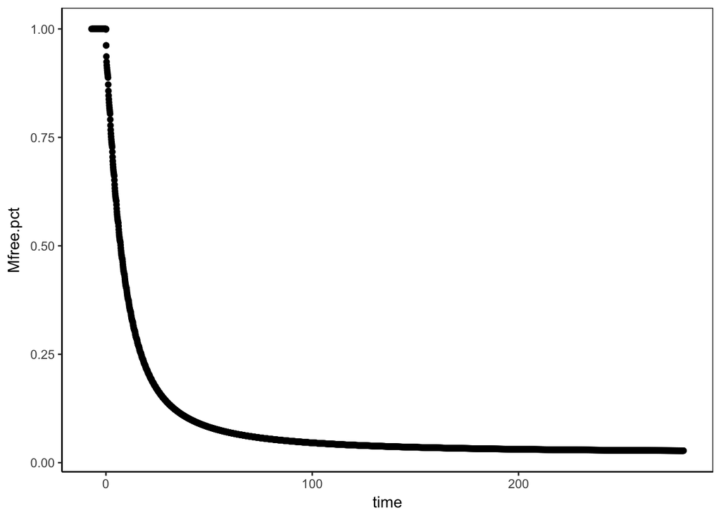

```r
g = ggplot(df, aes(time, Mfree.pct)) + geom_point()
print(g)
```